# L16: R Markdown & R Notebooks

## Chunk Options

### `echo` — show the code or not?

`echo = FALSE` runs the code and shows only the **output** — the code itself is hidden. Useful for clean reports where readers only care about results.

```
##      displ            hwy             cty
##  Min.   :1.600   Min.   :12.00   Min.   : 9.00
##  1st Qu.:2.400   1st Qu.:18.00   1st Qu.:14.00
##  Median :3.300   Median :24.00   Median :17.00
##  Mean   :3.472   Mean   :23.44   Mean   :16.86
##  3rd Qu.:4.600   3rd Qu.:27.00   3rd Qu.:19.00
##  Max.   :7.000   Max.   :44.00   Max.   :35.00
```

### `include` — run silently, show nothing

`include = FALSE` runs the code but hides **everything** — no code, no output, no messages. This is what the setup chunk at the top uses.

### `fig.width` and `fig.height`

Control the plot size **in inches**. Default is `fig.width = 7, fig.height = 5`.

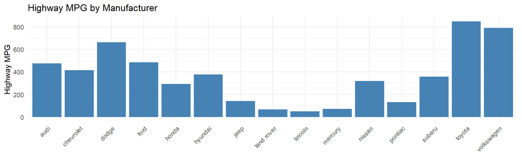

```r
# A wide, short figure — note the chunk header: fig.width=10, fig.height=3
ggplot(mpg, aes(x = manufacturer, y = hwy)) +
  geom_col(fill = "steelblue") +
  labs(title = "Highway MPG by Manufacturer", x = NULL, y = "Highway MPG") +
  theme_minimal() +
  theme(axis.text.x = element_text(angle = 45, hjust = 1))
```

### `fig.cap` — add a caption to figures

`fig.cap = "..."` adds a caption below graphical output:

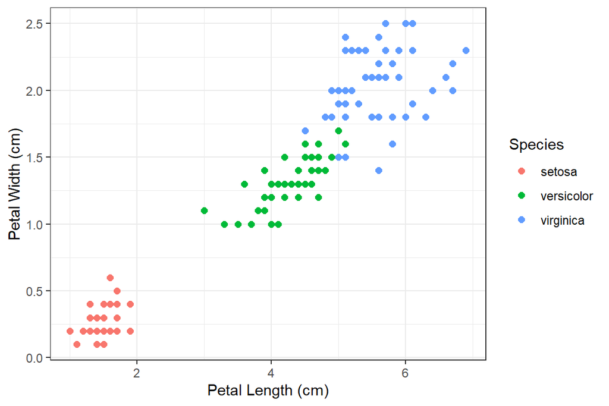

Figure 1. Petal length vs petal width, coloured by species.

```r
ggplot(iris, aes(x = Petal.Length, y = Petal.Width, colour = Species)) +
  geom_point(size = 2) +
  labs(x = "Petal Length (cm)", y = "Petal Width (cm)") +
  theme_bw()
```

### `warning`, `message`, and `error` — suppress R noise

Whether to show warnings, messages, and errors in the output document.

- `warning = FALSE` suppresses warning messages.
- `message = FALSE` suppresses informational messages (e.g. from `library()`).
- Both are set globally in the setup chunk at the top of this file.

### `cache` — skip re-running expensive chunks

`cache = TRUE` saves the chunk’s result on first run. On subsequent knits, the chunk is **skipped** and the saved result is reused — saving time for slow computations.

````r
# Example: a slow computation you don't want to re-run every time
# ```{r slow-model, cache = TRUE}
# big_model <- lm(hwy ~ ., data = mpg)
# ```
````

Many more options at: https://yihui.org/knitr/options/#chunk-options

## Global Chunk Options

If a certain option needs to be frequently set in multiple chunks, set it **globally** in the first code chunk of your document:

```r
# Place this in your setup chunk:
knitr::opts_chunk$set(fig.width = 8, collapse = TRUE)
```

Individual chunks can still **override** a global default by specifying the option locally in their own header.

Look at the setup chunk at the top of this file — it sets `echo = TRUE`, `warning = FALSE`, and `message = FALSE` for the whole document.

## Coding Challenge

Work through these steps in RStudio:

1. **Create a new R Markdown document** that outputs to HTML (`File > New File > R Markdown...`, choose HTML).
2. **Add an introduction** that describes the `iris` dataset — what it contains, how many rows, what the variables are.
3. **Create a scatterplot** of petal length vs petal width, coloured by species.
4. **Add a figure caption** using the `fig.cap` chunk option.

## R Notebooks

An **R Notebook** is an R Markdown document with chunks that can be executed independently and interactively, with output visible immediately beneath the input.

- Any R Markdown document can be used as a notebook, and all R Notebooks can be rendered to other R Markdown document types.
- A notebook can therefore be thought of as a **special execution mode** for R Markdown documents.
- Notebooks are a good choice **while authoring** the document and iterating on code.

### Creating a notebook

You can create a new notebook from the menu: **File > New File > R Notebook**.

You can also take an existing R Markdown doc and set the output to `html_notebook` in the YAML metadata:

```yaml
---
title: "My Notebook"
output: html_notebook
---
```

### Use code chunks effectively

As a chunk’s output appears beneath the chunk, it is helpful to **split chunks that produce multiple outputs** into two or more chunks which each produce only one output.

To do this, select the code to split, then use the new chunk keyboard shortcut (**Cmd+Option+I**, or **Ctrl+Alt+I**).

*End of L16 tutorial. Knit this file to see the finished report.*